# Quantifying Australia’s Plant Endemicity Using Global Datasets.

Stephanie Woolley (z5284998)

**The 4 main aims of this research were to:**  
1. Quantify how many plant species are endemic?  
2. What is the extinction risk status of endemic and non-endemic species?  
3. How do the growth forms differ between endemic and non-endemic species?  
4. What is the connection and distribution of non-endemic natives across the rest of the world?

## IntialPackage Installation:

the following packages are needed:

```r
#package installation
#devtools::install_github("wcornwell/taxonlookup")
#remotes::install_github("traitecoevo/austraits", build_vignettes = FALSE)
#install.packages("treemap")
#install.packages("AUstraits")
#install.packages("dpylr")
#install.packages("RColorBrewer")
#install.packages("rnaturalearth")
#install.packages("rnaturalearthdata")
#install.packages("ggplot2")
#install.packages("tidyverse")
#install.packages("highcharter")
library(austraits)
library(dplyr)
library(treemap)
library("RColorBrewer")
library(ggplot2)
library(rnaturalearth)
library(rnaturalearthdata)
library(tidyverse)
library(taxonlookup)
library(highcharter)
```

## 1. Initial data set:

Data manipulation was done by our supervisor W. Cornwell and uploaded as a complete Australian Native data frame with the exception of the joining of the invasive species data frames which is shown below.

**1.1Combining Invasive species data sets:**

**US alien invasive flora:**

```r
gris_us <- read.csv("https://raw.githubusercontent.com/stephwoolley/australian_plant_endemism/master/intermediate_data/gris_us_data.csv")

us_alien <- select(gris_us, scientificName, isInvasive, establishmentMeans)

us_inv <- us_alien %>%
  filter(isInvasive == "Invasive")

us_inv_rename <- rename(us_inv, species = scientificName, for_USA = isInvasive)

write.csv(us_inv_rename, "intermediate_data/US_invasive_method_1.csv")
```

**iNaturalist invasive:**

```r
natives_wc<- read.csv("https://raw.githubusercontent.com/stephwoolley/australian_plant_endemism/master/intermediate_data/natives_with_counties_added.csv")
ausinv <- read.csv("https://raw.githubusercontent.com/stephwoolley/australian_plant_endemism/master/data/aus_invasives_elsewhere.csv")

ausinv <- select(ausinv, -group)
ausinv <- rename(ausinv, 'canonicalName' = species)

join_na_ausinv <- left_join(natives_wc, ausinv, by = "canonicalName")
 write.csv("natives_with_invasives_method2.csv")
```

```
## "","x"
## "1","natives_with_invasives_method2.csv"
```

**Glonaf invasive:**

```r
glonaf <- read.csv("https://raw.githubusercontent.com/stephwoolley/australian_plant_endemism/master/data/Taxon_x_List_GloNAF_vanKleunenetal2018Ecology.csv")
method_2="https://raw.githubusercontent.com/stephwoolley/australian_plant_endemism/master/intermediate_data/natives_with_invasives_method2.csv"
method_2<-read_csv(url(method_2))
glonaf <- rename(glonaf, 'canonicalName' = taxon_orig)
join_glonaf_method2 <-left_join(method_2, glonaf, by = "canonicalName")
write.csv("join_glonaf_method2.csv")
```

```
## "","x"
## "1","join_glonaf_method2.csv"
```

the invaisve species data sets were then used to create a subset dataframe called country_dataset.csv, this was then used for all the following data manipulation and visualisations.

## 2. Assessing Endemism:

```r
#import data
countries <- read.csv("https://raw.githubusercontent.com/stephwoolley/australian_plant_endemism/master/intermediate_data/country_dataset.csv")

#number of endemic species
countries%>%
  group_by(aus_endemic) %>%
  summarise(endemic_subset=n())
```

```
## # A tibble: 2 × 2
##   aus_endemic endemic_subset
##   <lgl>                <int>
## 1 FALSE                 2693
## 2 TRUE                 18375
```

joining with taxon lookup to get group counts:

```r
countries$genus <- word(countries$species,1,1)

lt <- lookup_table(countries$species, by_species = TRUE)
lt <- rownames_to_column(lt, "species")

native_species_wgroups <- left_join(countries, lt)
native_species_wgroups %>%
  group_by(group) %>%
  summarize(prop_endemic = sum(aus_endemic)/n(), n=n())
```

```
## # A tibble: 4 × 3
##   group         prop_endemic     n
##   <chr>                <dbl> <int>
## 1 Angiosperms          0.883 20279
## 2 Gymnosperms          0.918   122
## 3 Pteridophytes        0.423   471
## 4 <NA>                 0.847   196
```

```r
subset <- select(native_species_wgroups, species, group, aus_endemic)
```

endemic groups number of species:

```r
endemic_subset <- subset %>%
  group_by(group) %>%
  filter(aus_endemic == "TRUE")

endemic_subset%>%
  group_by(group) %>%
  summarise(endemic_subset=n())
```

```
## # A tibble: 4 × 2
##   group         endemic_subset
##   <chr>                  <int>
## 1 Angiosperms            17898
## 2 Gymnosperms              112
## 3 Pteridophytes            199
## 4 <NA>                     166
```

non-endemic groups number of species:

```r
nonendemic_subset <- subset %>%
  group_by(group) %>%
  filter(aus_endemic == "FALSE")

nonendemic_subset%>%
  group_by(group) %>%
  summarise(nonendemic_subset=n())
```

```
## # A tibble: 4 × 2
##   group         nonendemic_subset
##   <chr>                     <int>
## 1 Angiosperms                2381
## 2 Gymnosperms                  10
## 3 Pteridophytes               272
## 4 <NA>                         30
```

**2.2 Joining IUCN plots:** the following code was used to join IUCN data:

```r
country <- read.csv("https://raw.githubusercontent.com/stephwoolley/australian_plant_endemism/master/intermediate_data/country_dataset.csv")

ICUN <- read.csv("https://raw.githubusercontent.com/stephwoolley/australian_plant_endemism/master/intermediate_data/assessments.csv")

ICUN <- rename(ICUN, 'species' = scientificName)

ICUN_subset <- select(ICUN, species, redlistCategory)

joined_data <- left_join(country, ICUN_subset, by = "species")

subset <- select(joined_data, species, redlistCategory, aus_endemic)
```

endemic IUCN status:

```r
#endemic
endemic_subset <- subset %>%
  group_by(aus_endemic) %>%
  filter(aus_endemic == "TRUE")

endemic_subset %>%
  group_by(redlistCategory) %>%
  summarise(endemic_subset=n())
```

```
## # A tibble: 8 × 2
##   redlistCategory            endemic_subset
##   <chr>                               <int>
## 1 Critically Endangered                  91
## 2 Data Deficient                         91
## 3 Endangered                            271
## 4 Least Concern                        2000
## 5 Lower Risk/near threatened              1
## 6 Near Threatened                       231
## 7 Vulnerable                            386
## 8 <NA>                                15304
```

non-endemic IUCN status:

```r
#nonendemic
nonendemic_subset <- subset %>%
  group_by(aus_endemic) %>%
  filter(aus_endemic == "FALSE")

 nonendemic_subset %>%
  group_by(redlistCategory) %>%
  summarise(nonendemic_subset=n())
```

```
## # A tibble: 8 × 2
##   redlistCategory            nonendemic_subset
##   <chr>                                  <int>
## 1 Data Deficient                            10
## 2 Endangered                                 3
## 3 Least Concern                            681
## 4 Lower Risk/least concern                   6
## 5 Lower Risk/near threatened                 2
## 6 Near Threatened                           15
## 7 Vulnerable                                 4
## 8 <NA>                                    1972
```

**2.3 Joining Growth form data and creating growth form plots:**

creating growth form dataset:

```r
#austraits growth form data set
austraits <- load_austraits(version = "3.0.2", path = "intermediate_data/austraits")
```

```
## Loading data from 'intermediate_data/austraits/austraits-3.0.2.rds'
```

```r
#create new data frame with just the growth form values
growth_form <- filter(austraits$traits, trait_name == "plant_growth_form")

#select only necessary info
growth_form_subset <- select(growth_form, taxon_name, value)

#select only first one of each canonical name
growth_form <- growth_form_subset %>%
  distinct(taxon_name, .keep_all = TRUE)

#Endemic and non-endemic treemap process
#load endemic dataset
country <- read.csv("https://raw.githubusercontent.com/stephwoolley/australian_plant_endemism/master/intermediate_data/country_dataset.csv")

#rename taxon to match name_use
growth_form <- rename(growth_form, 'species' = taxon_name)

#join two datasets
join_data <- left_join(country, growth_form, by = "species")

#create larger groupings using recode
complete_group <- join_data %>%
  group_by(value) %>%
  mutate (group = recode(value,
                         climber_herb = "climber",
                         climber_liana = "climber",
                         climber_palm = "climber",
                         "climber_liana climber_vine" = "climber",
                         climber_scrambler = "climber",
                         climber_shrub = "climber",
                         climber_twiner = "climber",
                         climber_vine = "climber",
                         climber_vine_herbaceous = "climber",
                         climber_vine_woody = "climber",
                         climber_woody = "climber",
                         "climber_shrub climber_tree" = "climber",
                         aquatic_herb = "aquatic",
                         "epiphyte parasite" = "epiphyte",
                         fern_tree = "fern",
                         graminoid_tussock = "graminoid",
                         "hemi-epiphyte" = "epiphyte",
                         "herb shrub" = "herb",
                         "herb subshrub" = "herb",
                         herb_large = "herb",
                         parasite_woody = "parasite",
                         prostrate_herb = "prostrate",
                         prostrate_shrub = "prostrate",
                         rosette_erect = "rosette",
                         "shrub subshrub" = "shrub",
                         "shrub tree" = "shrub",
                         "shrub treelet" = "shrub",
                         subshrub = "shrub",
                         treelet ="tree",
                         cushion = "herb",
                         climber_shrub_climber_tree = "climber",
                         erect_leafy = "herb",
                         long_basal = "herb",
                         "rosette" = "herb",
                         rosette_erect = "herb",
                         semi_basal = "herb",
                         short_basal = "herb",
                         succulent_short = "succulent",
                         "epiphyte_herb" = "epiphyte"
  ))

#select only necessary info
complete_group <- select(complete_group, species, value, aus_endemic, group)
```

Creating endemic growth form tree map from dataframe:

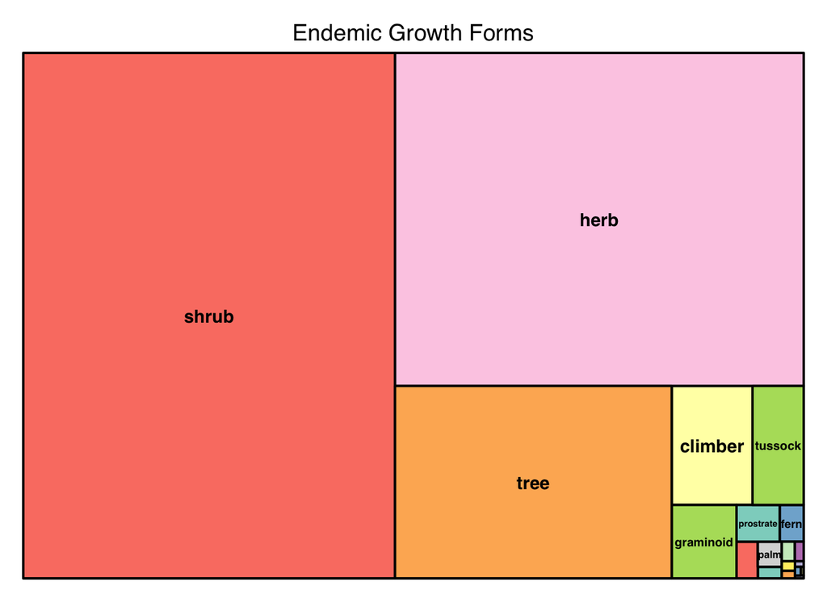

```r
#subset so only endemic
endemic_group <- complete_group %>%
  group_by(aus_endemic) %>%
  filter(aus_endemic == "TRUE")
#endemic treemap of large groups data
endemic_group_counts <- endemic_group %>%
  group_by(group) %>%
  summarise(num_species=n())

treemap(endemic_group_counts,
        index= "group",
        vSize="num_species",
        type="index",
        palette = "Set3",
        title = "Endemic Growth Forms")
```

Creating non-endemic growth form treemap from dataframe:

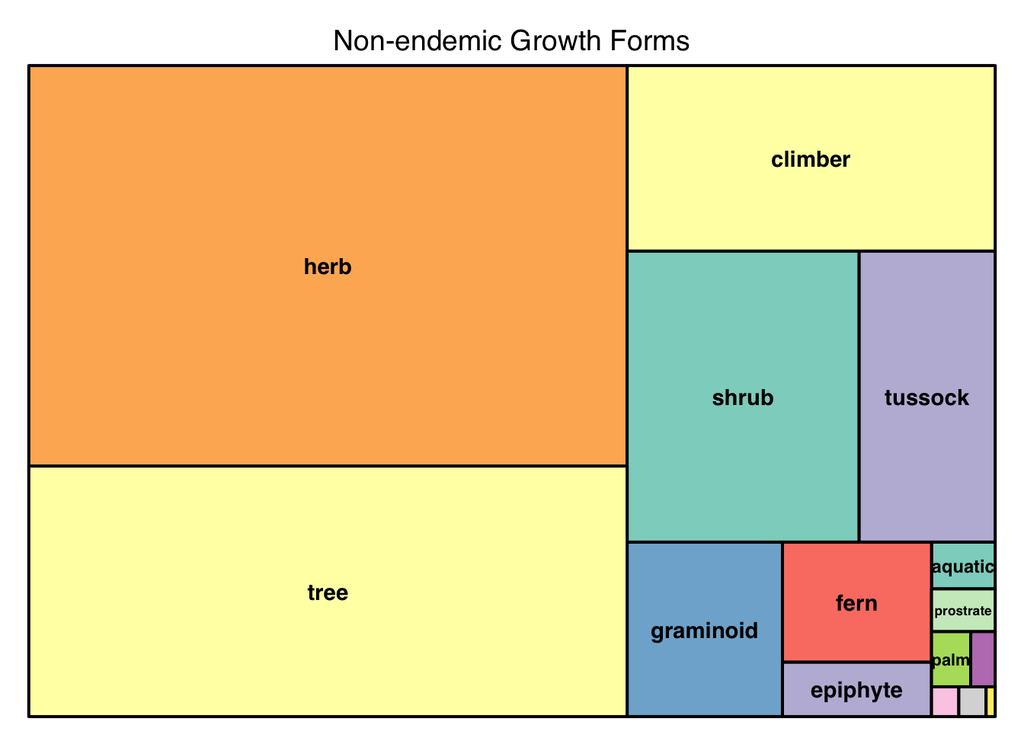

```r
#subset so nonendemic
nonendemic_group <- complete_group %>%
  group_by(aus_endemic) %>%
  filter(aus_endemic == "FALSE")

#nonendemic treemap of large groups data
nonendemic_group_counts <- nonendemic_group %>%
  group_by(group) %>%
  summarise(num_species=n())

treemap(nonendemic_group_counts,
        index= "group",
        vSize="num_species",
        type="index",
        palette = "Set3",
        title = "Non-endemic Growth Forms")
```

**Plus an interactive endemic treemap for fun!**

```r
options(highcharter.theme = hc_theme_smpl(tooltip = list(valueDecimals = 2)))

endemic_group_counts <- na.omit(endemic_group_counts)

hc <- endemic_group_counts %>%
  hchart(
    "treemap",
    hcaes(x = group, value = num_species, color = value)
  )
hc
```

[interactive chart not shown]

**2.4 Creating Geographical Visulisations:** The geographical visualisations are accessible on the rmd file version of this HTMl.